# Tourism Charts

David Alexander

03/01/2020

### Introduction

This page contains the data and analysis of all the charts in the Tourism State of the Park paper. The data tables are printed out so the underlaying data can be seen.

This data is processed using the https://www.tidyverse.org/packages/ packages in R

### Figure 1: STEAM Volume of visits in Visitor Days and Visitor Numbers 2009-2018

- **Data Source:** STEAM model Peak District and Influence Area https://www.globaltourismsolutions.co.uk/steam-model/
- **Next Updated:** Autumn 2020

```r
# Read the data
fig1 <- read_csv("Tourism_Data/Figure_1.csv")
# View the data
as_tibble(fig1)
```

```
## # A tibble: 20 x 3
##    Visit_Type      Millions  Year
##    <chr>              <dbl> <dbl>
##  1 Visitor_Numbers     8.94  2009
##  2 Visitor_Numbers     8.67  2010
##  3 Visitor_Numbers     9.11  2011
##  4 Visitor_Numbers     8.84  2012
##  5 Visitor_Numbers     8.75  2013
##  6 Visitor_Numbers     8.90  2014
##  7 Visitor_Numbers     9.06  2015
##  8 Visitor_Numbers     9.06  2016
##  9 Visitor_Numbers     9.82  2017
## 10 Visitor_Numbers     9.91  2018
## 11 Visitor_Days       11.9   2009
## 12 Visitor_Days       11.7   2010
## 13 Visitor_Days       12.2   2011
## 14 Visitor_Days       11.9   2012
## 15 Visitor_Days       11.8   2013
## 16 Visitor_Days       12.1   2014
## 17 Visitor_Days       12.2   2015
## 18 Visitor_Days       12.3   2016
## 19 Visitor_Days       13.2   2017
## 20 Visitor_Days       13.4   2018
```

```r
# plot a graph
fig1_p <- ggplot(data = fig1, aes(x=Year, y=Millions, fill=Visit_Type)) +
  geom_bar(stat = "identity", position=position_dodge()) +
  scale_fill_manual(values=c("#999999", "#8d395b")) +
  xlab("Year") + ylab("Millions (000's)") +
  ggtitle("Figure 1: STEAM Volume of visits in Visitor Days & Visitor Numbers 2009-2018") +
  coord_cartesian(xlim =c(2009, 2018)) +
  theme_minimal()

# output a plot
ggplotly(fig1_p) %>%
  layout(legend = list(orientation = "h", x = 0.4, y = -0.2))
```

[interactive chart not shown]

#### Figure 2: STEAM Volume of visits in Visitor Days per month (Year 2018)

- **Data Source:** STEAM model Peak District and Influence Area https://www.globaltourismsolutions.co.uk/steam-model/
- **Next Updated:** Autumn 2020

```r
# read data
fig2 <- read_csv("Tourism_Data/Figure_2.csv")

# order a factor for plotting
fig2$Month <- factor(fig2$Month, levels = month.abb)

# View the data
as_tibble(fig2)
```

```
## # A tibble: 12 x 2
##    Month Visitor_Days
##    <fct>        <dbl>
##  1 Jan          48169
##  2 Feb          63895
##  3 Mar          74255
##  4 Apr         129804
##  5 May         154805
##  6 Jun         138149
##  7 Jul         162137
##  8 Aug         173481
##  9 Sep         158221
## 10 Oct         104696
## 11 Nov          74111
## 12 Dec          61724
```

```r
# plot a graph
fig2_p <- ggplot(data = fig2, aes(x=Month, y=Visitor_Days, group=1)) +
  geom_line(colour = "#8d395b") +
  xlab("Month 2018") + ylab("Visitor Days") +
  ggtitle("Figure 2: STEAM Volume of visits in Visitor Days per month 2018") +
  theme_minimal()

# output a plot
ggplotly(fig2_p)
```

[interactive chart not shown]

#### Figure 3: STEAM Sectoral Distribution of Economic Impact; Tourist Expenditure (£Million 2009-2018 VAT indexed 2017)

- **Data Source:** STEAM model Peak District and Influence Area https://www.globaltourismsolutions.co.uk/steam-model/
- **Next Updated:** Autumn 2020

[output not shown]

#### Figure 4: Economic Activity Visitor Survey 2015

- **Data Source:** Peak District National Park Visitor Survey 2014/15
- **Next Updated:** TBC

```r
# read data
fig4 <- read_csv("Tourism_Data/Figure_4.csv")

# View the data
as_tibble(fig4)
```

```
## # A tibble: 8 x 2
##   Economic_Activity            Percentage
##   <chr>                             <dbl>
## 1 Employed                          0.51
## 2 Retired                           0.21
## 3 Student                           0.15
## 4 Under 16                          0.1
## 5 Other                             0.015
## 6 Unemployed                        0.007
## 7 Carer / Looking after family      0.003
## 8 Sick / Disabled                   0.003
```

```r
colors <- c('rgb(141,57,91)', 'rgb(128,133,133)', 'rgb(144,103,167)', 'rgb(171,104,87)','rgb(114,147,203)','rgb(144,103,167)', 'rgb(171,104,87)', 'rgb(114,147,203)')

fig4_p <- plot_ly(fig4, labels = ~Economic_Activity, values = ~Percentage, type = 'pie',
        textposition = 'inside',
        textinfo = 'label+percent',
        insidetextfont = list(color = '#FFFFFF'),
        hoverinfo = 'text',
        text = ~paste(Economic_Activity, Percentage * 100,'%'),
        marker = list(colors = colors,
                      line = list(color = '#FFFFFF', width = 1)),
                      #The 'pull' attribute can also be used to create space between the sectors
        showlegend = FALSE) %>%
  layout(title = 'Figure 4: Economic Activity Visitor Survey 2015',
         xaxis = list(showgrid = FALSE, zeroline = FALSE, showticklabels = FALSE),
         yaxis = list(showgrid = FALSE, zeroline = FALSE, showticklabels = FALSE))

# output a plot
ggplotly(fig4_p)
```

[interactive chart not shown]

#### Figure 5: Group Size Visitor Survey 2015

- **Data Source:** Peak District National Park Visitor Survey 2014/15
- **Next Updated:** TBC

```r
# Read the data
fig5 <- read_csv("Tourism_Data/Figure_5.csv")
# View the data
as_tibble(fig5)
```

```
## # A tibble: 5 x 2
##   Group_Size  Percentage
##   <chr>            <dbl>
## 1 1 Person            19
## 2 2 People            44
## 3 3-4 People          24
## 4 5-10 People         10
## 5 10+ People           4
```

```r
# plot a graph
fig5_p <- plot_ly(fig5, x = ~Group_Size, y = ~Percentage, type = 'bar', color = I("#8d395b")) %>%
  layout(title = "Figure 5: Group Size Visitor Survey 2015 ",
         xaxis = list(title = "Group Size"),
         yaxis = list(title = "Percentage"))

# output a plot
fig5_p
```

[interactive chart not shown]

#### Figure 6: Visitor Origin by Region

- **Data Source:** Peak District National Park Visitor Survey 2014/15
- **Data Source:** http://geoportal.statistics.gov.uk/datasets/4fcca2a47fed4bfaa1793015a18537ac_4
- **Next Updated:** TBC

```r
# Load the extra libraries for maping
library("GISTools")
RegionSP <- readShapePoly("~/GitHub/stateoftheparkcontent/Tourism_Data/SP/Regions_December_2017_Ultra_Generalised_Clipped_Boundaries_in_England.shp")
# Read the data
fig6 <- read_csv("Tourism_Data/Figure_6.csv")
# View the data
##################as_tibble(fig6)
```

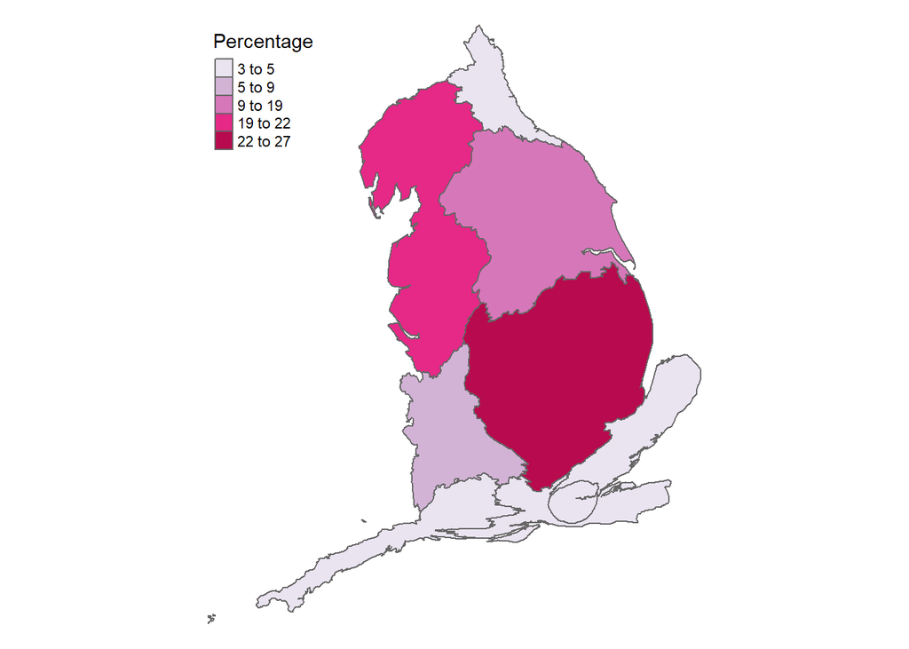

```r
# Load the extra Libraries
library(cartogram)
library(tmap)
#library(broom)
# Merge the data to the SP boundary
RegionSP <- merge(RegionSP, fig6, by.x="rgn17nm", by.y="Region")

#Create Cartogram & Choropleth
fig6_p <- cartogram(RegionSP, "Percentage", itermax=7)

tm_shape(fig6_p) + tm_polygons("Percentage", style = "jenks", palette = "PuRd") +
  tm_layout(frame = FALSE, legend.position = c("left", "top"))
```

#### Figure 7: Knowledge about the Peak District

- **Data Source:** Peak District National Park Non Visitor Survey 2014/15
- **Next Updated:** TBC

```r
# Read the data
fig7 <- read_csv("Tourism_Data/Figure_7.csv")
# View the data
as_tibble(fig7)
```

```
## # A tibble: 4 x 2
##   Knowledge                 Percentage
##   <chr>                          <dbl>
## 1 Not aware of the Park             32
## 2 Heard of the Park                 45
## 3 Know a bit about the Park         21
## 4 Know a lot about the Park          3
```

```r
# plot a graph
fig7_p <- plot_ly(fig7, x = ~Knowledge, y = ~Percentage, type = 'bar', color = I("#8d395b")) %>%
  layout(title = "Figure 7: Knowledge about the Peak District",
         xaxis = list(title = "Knowledge about the Park", tickangle = -0),
         yaxis = list(title = "Percentage"))

# output a plot
fig7_p
```

[interactive chart not shown]

#### Figure 8: Likelihood to visit the National Park in the future

- **Data Source:** Peak District National Park Visitor Survey 2014/15
- **Next Updated:** TBC

```r
# Read the data
fig8 <- read_csv("Tourism_Data/Figure_8.csv")
# View the data
as_tibble(fig8)
```

```
## # A tibble: 5 x 2
##   Likelihood     Percentage
##   <chr>               <dbl>
## 1 Very likely            12
## 2 Quite likely           30
## 3 Neither                19
## 4 Quite unlikely         14
## 5 Very unlikely          24
```

```r
# plot a graph
fig8_p <- plot_ly(fig8, x = ~Likelihood, y = ~Percentage, type = 'bar', color = I("#8d395b")) %>%
  layout(title = "Figure 8: Likelihood to visit the National Park in the future",
         xaxis = list(title = "Likelihood to visit the Park"),
         yaxis = list(title = "Percentage"))

# output a plot
fig8_p
```

[interactive chart not shown]

#### Figure 9: ACORN Results: Proportion of postcodes per ACORN Category

- **Data Source:** Peak District National Park Non / Visitor Survey 2014/15
- **Data Source:** https://acorn.caci.co.uk/
- **Next Updated:** TBC

```r
# Read the data
fig9 <- read_csv("Tourism_Data/Figure_9.csv")
# View the data
as_tibble(fig9)
```

```
## # A tibble: 6 x 7
##   Acorn `Greater Manche… `Non-Visitor: M… `Non-Visitor: S… `Non-Visitors`
##   <chr> <chr>            <chr>            <chr>            <chr>
## 1 Cate… 20%              4%               5%               5%
## 2 Cate… 5%               3%               1%               2%
## 3 Cate… 22%              10%              19%              15%
## 4 Cate… 25%              33%              35%              34%
## 5 Cate… 27%              48%              38%              42%
## 6 Cate… 1%               3%               3%               3%
## # … with 2 more variables: Visitors <chr>, GB <chr>
```

```r
kable(fig9) %>%
  kable_styling(bootstrap_options = "striped", "condensed", full_width = F)
```

| Acorn | Greater Manchester | Non-Visitor: Manchester | Non-Visitor: Sheffield | Non-Visitors | Visitors | GB |
| --- | --- | --- | --- | --- | --- | --- |
| Category 1 Affluent Achievers | 20% | 4% | 5% | 5% | 33% | 23% |
| Category 2 Rising Prosperity | 5% | 3% | 1% | 2% | 5% | 9% |
| Category 3 Comfortable Communities | 22% | 10% | 19% | 15% | 33% | 27% |
| Category 4 Financially Stretched | 25% | 33% | 35% | 34% | 18% | 23% |
| Category 5 Urban Adversity | 27% | 48% | 38% | 42% | 10% | 18% |
| Category 6 Not Private Households | 1% | 3% | 3% | 3% | 1% | 1% |

#### Figure 10: Figure 10: Monthly Visitor Centre Contacts 2018

- **Data Source:** Peak District National Park Authority
- **Next Updated:** Autumn 2020

```r
# read data
fig10 <- read_csv("Tourism_Data/Figure_10.csv")

# order a factor for plotting
fig10$Month <- factor(fig10$Month, levels = month.abb)

# View the data
as_tibble(fig10)
```

```
## # A tibble: 12 x 2
##    Month Contacts
##    <fct>    <dbl>
##  1 Jan      20202
##  2 Feb      22784
##  3 Mar      21313
##  4 Apr      37704
##  5 May      44934
##  6 Jun      41681
##  7 Jul      46839
##  8 Aug      61630
##  9 Sep      38058
## 10 Oct      39370
## 11 Nov      27880
## 12 Dec      30944
```

```r
# plot a graph
fig10_p <- ggplot(data = fig10, aes(x=Month, y=Contacts, group=1)) +
  geom_line(colour = "#8d395b") +
  xlab("Month") + ylab("Number of Contacts") +
  ggtitle("Figure 10: Figure 10: Monthly Visitor Centre Contacts 2018") +
  theme_minimal()

# output a plot
ggplotly(fig10_p)
```

[interactive chart not shown]

- **Data Source:** STEAM model Peak District and Influence Area https://www.globaltourismsolutions.co.uk/steam-model/
- **Next Updated:** Autumn 2020

```r
# Read the data
fig11 <- read_csv("Tourism_Data/Figure_11.csv")
# View the data
as_tibble(fig11)
```

```
## # A tibble: 5 x 3
##   `Tourist Information C… `Average 9 year number of con… `Percentage of total c…
##   <chr>                                            <dbl> <chr>
## 1 Bakewell                                        161563 41%
## 2 Edale                                            32144 8%
## 3 Derwent                                          40471 10%
## 4 Castleton                                       163208 41%
## 5 Total (9 year Average)                          397386 <NA>
```

```r
kable(fig11) %>%
  kable_styling(bootstrap_options = "striped", "condensed", full_width = F)
```

| Tourist Information Centre | Average 9 year number of contacts per year | Percentage of total contacts |
| --- | --- | --- |
| Bakewell | 161563 | 41% |
| Edale | 32144 | 8% |
| Derwent | 40471 | 10% |
| Castleton | 163208 | 41% |
| Total (9 year Average) | 397386 | NA |

#### Figure 12: Cyclists & Walkers 2 way counts Hassop Station Monsal Trail 2017

- **Data Source:** Peak District National Park Authority
- **Next Updated:** Autumn 2020

```r
# read data
fig12 <- read_csv("Tourism_Data/Figure_12.csv")

# order a factor for plotting
fig12$Month <- factor(fig12$Month, levels = month.abb)

# View the data
as_tibble(fig12)
```

```
## # A tibble: 24 x 3
##    Month Mode    Count
##    <fct> <chr>   <dbl>
##  1 Jan   Walkers 10616
##  2 Feb   Walkers 12011
##  3 Mar   Walkers 13640
##  4 Apr   Walkers 24434
##  5 May   Walkers 20007
##  6 Jun   Walkers 16628
##  7 Jul   Walkers 20028
##  8 Aug   Walkers 30687
##  9 Sep   Walkers 21406
## 10 Oct   Walkers 28872
## # … with 14 more rows
```

```r
# plot a graph
fig12_p <- ggplot(data = fig12, aes(x=Month, y=Count, group=Mode)) +
  geom_line(colour = "#8d395b") +
  xlab("Month") + ylab("Number") +
  ggtitle("Figure 12: Cyclists & Walkers 2 way counts Hassop Station Monsal Trail 2017") +
  theme_minimal()

# output a plot
ggplotly(fig12_p)
```

[interactive chart not shown]

#### Figure 13: Serviced Accommodation 2017 STEAM Bed Spaces

- **Data Source:** STEAM model Peak District and Influence Area https://www.globaltourismsolutions.co.uk/steam-model/
- **Next Updated:** Autumn 2020

```r
# Read the data
fig13 <- read_csv("Tourism_Data/Figure_13.csv")
# View the data
as_tibble(fig13)
```

```
## # A tibble: 4 x 4
##   `SERVICED ACCOMMODATION` Establishments  Beds Percentage
##   <chr>                             <dbl> <dbl> <chr>
## 1 +50 Room                              6  1174 19%
## 2 11-50 Room                           46  1916 31%
## 3 <10 Room                            407  2998 49%
## 4 Total                               459  6088 100%
```

```r
kable(fig13) %>%
  kable_styling(bootstrap_options = "striped", "condensed", full_width = F)
```

| SERVICED ACCOMMODATION | Establishments | Beds | Percentage |
| --- | --- | --- | --- |
| +50 Room | 6 | 1174 | 19% |
| 11-50 Room | 46 | 1916 | 31% |
| <10 Room | 407 | 2998 | 49% |
| Total | 459 | 6088 | 100% |

#### Figure 14: Non-Serviced Accommodation 2017

- **Data Source:** STEAM model Peak District and Influence Area https://www.globaltourismsolutions.co.uk/steam-model/
- **Next Updated:** Autumn 2020

```r
# Read the data
fig14 <- read_csv("Tourism_Data/Figure_14.csv")
# View the data
as_tibble(fig14)
```

```
## # A tibble: 5 x 4
##   `NON-SERVICED ACCOMMODATION` Establishments  Beds Percentage
##   <chr>                                 <dbl> <dbl> <chr>
## 1 Self-catering                          1001  6540 30%
## 2 Static caravans/chalets                   0  1167 5%
## 3 Touring caravans/camping                131 12627 57%
## 4 Youth Hostels                            34  1724 8%
## 5 Total                                  1166 22058 100%
```

```r
kable(fig14) %>%
  kable_styling(bootstrap_options = "striped", "condensed", full_width = F)
```

| NON-SERVICED ACCOMMODATION | Establishments | Beds | Percentage |
| --- | --- | --- | --- |
| Self-catering | 1001 | 6540 | 30% |
| Static caravans/chalets | 0 | 1167 | 5% |
| Touring caravans/camping | 131 | 12627 | 57% |
| Youth Hostels | 34 | 1724 | 8% |
| Total | 1166 | 22058 | 100% |

#### Figure 15: Seasonal Availability of bed supply STEAM 2018

- **Data Source:** STEAM model Peak District and Influence Area https://www.globaltourismsolutions.co.uk/steam-model/
- **Next Updated:** Autumn 2020

```r
# Read the data
fig15 <- read_csv("Tourism_Data/Figure_15.csv")
# View the data
as_tibble(fig15)
```

```
## # A tibble: 24 x 3
##    Month Type                  Count
##    <chr> <chr>                 <dbl>
##  1 Jan   Serviced Accomodation  6002
##  2 Feb   Serviced Accomodation  6002
##  3 Mar   Serviced Accomodation  6088
##  4 Apr   Serviced Accomodation  6088
##  5 May   Serviced Accomodation  6088
##  6 Jun   Serviced Accomodation  6088
##  7 Jul   Serviced Accomodation  6088
##  8 Aug   Serviced Accomodation  6088
##  9 Sep   Serviced Accomodation  6088
## 10 Oct   Serviced Accomodation  6088
## # … with 14 more rows
```

```r
# plot a graph
fig15_p <- ggplot(data = fig15, aes(x=Month, y=Count, fill=Type)) +
  geom_bar(stat = "identity", position="stack") +
  scale_fill_manual(values=c("#999999", "#8d395b")) +
  xlab("Month") + ylab("Bed Supply") +
  ggtitle("Figure 15: Seasonal Availability of bed supply STEAM 2018") +
  theme_minimal()

# output a plot
ggplotly(fig15_p) %>%
  layout(legend = list(orientation = "h", x = 0.4, y = -0.2))
```

[interactive chart not shown]